# Practical 1: Basics of Spatial Data in R

Rocco Bowman

5/31/2021

## 1.0 Introduction

This first lesson will introduce/refresh you on the basics of loading, manipulating, and saving spatial data in **R**. As always, there are more than one way to do things in R so consider the following code (and all subsequent lessons) as *one* way to do things.

## 1.1 Find some data

*You can use the data included in the course materials or you may find your own data. Put your data in the “data” folder to access it.*

First we should establish our **working directory**. An easy way to do this is to select the console, press **crtl** + **shift** + **H**, choose your course folder, then copy-paste the output into your script.

This code sets your working directory (setwd = “set working directory”). You can use the key combo above in the console to select your course folder then copy paste the command into a script if needed.

```r
setwd("C:/Users/bowma/Desktop/GIS Mini-course Summer 2021")
```

Now we can look inside our directory folders to find the name of the data we want to use. You may already know in which case you can skip this step.

This code allows you to look inside your working directory folder and see sub-directories or sub-folders. The “.” in the output denotes your directory folder

```r
list.dirs()
```

```
## [1] "."            "./Day 1"      "./Day 1/data" "./Day 2"      "./Day 3"
## [6] "./Day 4"      "./Day 5"
```

This code lists all the files currently present in your data folder within your working directory (“.”). You can replace “data” with scripts to see inside that folder as well.

```r
list.files("./Day 1/data")
```

```
## [1] "demographic.csv"       "nybb.dbf"              "nybb.prj"
## [4] "nybb.shp"              "nybb.shp.xml"          "nybb.shx"
## [7] "rent_observations.csv"
```

## 1.2 Loading Data

We will want the New York City boundary **(nybb)** file as well as the the **demographic** data. The demographic data is one **.csv** file but **nybb** has many files. We want to select just **nybb.shp**. This refers to the actual geometries of the boundaries but by loading in a **.shp** we also take advantage of the other files to specify its attribute and projection information.

Let’s load the demographic data first using **read.csv()** and look at the first five rows using **head()**.

```r
demographic <- read.csv("Day 1/data/demographic.csv")

head(demographic, n = 5)
```

```
##         borough year     pop under_5 under_18 over_65 female white black_aa
## 1         Bronx 2010 1418207    0.08    0.246   0.133  0.528 0.447    0.436
## 2      Brooklyn 2010 2559903    0.04    0.227   0.144  0.526 0.498    0.338
## 3     Manhattan 2010 1628706    0.01    0.143   0.170  0.526 0.646    0.178
## 4        Queens 2010 2253858    0.01    0.200   0.163  0.515 0.478    0.207
## 5 Staten Island 2010  476143    0.08    0.218   0.167  0.514 0.745    0.116
##   amer_ind asian haw_pi multi hisp_latino white_nohisp veterans foreign
## 1    0.029 0.046  0.004 0.038       0.564        0.090    25175   0.353
## 2    0.009 0.127  0.001 0.027       0.189        0.368    37191   0.361
## 3    0.012 0.128  0.002 0.034       0.256        0.472    31459   0.287
## 4    0.013 0.269  0.002 0.030       0.282        0.249    42135   0.472
## 5    0.007 0.109  0.001 0.022       0.186        0.596    14964   0.233
##   housing_units owner_occup median_val median_cost_mort median_cost_nomort
## 1        537232       0.197     404700             2467                795
## 2       1065399       0.301     706000             2903                909
## 3        892878       0.241     987700             3339               1057
## 4        869400       0.448     543800             2607                887
## 5        181751       0.693     504800             2535                905
```

## 1.3 Loading Spatial Data and Quick Visuals

Now let’s load in the New York boundary shapefile. We will need to first load in the **sf** package which allows us to easily use “simple feature” geometries or vector data.

```r
# If you do not have sf yet, you can enter 'install.packages("sf")' in the console.
library(sf)
```

Now with **sf** loaded, we can use **st_read** to load the shapefile.

```r
boundaries <- st_read("Day 1/data/nybb.shp")
```

Let’s check the first five rows of your shapefile. We now see a **geometry** column which tells R how to draw the vector shapes. We can also check the CRS or “Coordinate Reference System” of the shapefile.

```r
head(boundaries)
```

```
## Simple feature collection with 5 features and 4 fields
## Geometry type: MULTIPOLYGON
## Dimension:     XY
## Bounding box:  xmin: 913175.1 ymin: 120121.9 xmax: 1067383 ymax: 272844.3
## Projected CRS: NAD83 / New York Long Island (ftUS)
##   BoroCode      BoroName Shape_Leng Shape_Area                       geometry
## 1        5 Staten Island   326060.1 1623676769 MULTIPOLYGON (((970217 1456...
## 2        2         Bronx   464720.0 1187231178 MULTIPOLYGON (((1012822 229...
## 3        3      Brooklyn   729595.3 1934095186 MULTIPOLYGON (((1021176 151...
## 4        4        Queens   903938.4 3042317763 MULTIPOLYGON (((1032452 154...
## 5        1     Manhattan   359935.0  636605478 MULTIPOLYGON (((981219.1 18...
```

```r
st_crs(boundaries)
```

```
## Coordinate Reference System:
##   User input: NAD83 / New York Long Island (ftUS)
##   wkt:
## PROJCRS["NAD83 / New York Long Island (ftUS)",
##     BASEGEOGCRS["NAD83",
##         DATUM["North American Datum 1983",
##             ELLIPSOID["GRS 1980",6378137,298.257222101,
##                 LENGTHUNIT["metre",1]]],
##         PRIMEM["Greenwich",0,
##             ANGLEUNIT["degree",0.0174532925199433]],
##         ID["EPSG",4269]],
##     CONVERSION["SPCS83 New York Long Island zone (US Survey feet)",
##         METHOD["Lambert Conic Conformal (2SP)",
##             ID["EPSG",9802]],
##         PARAMETER["Latitude of false origin",40.1666666666667,
##             ANGLEUNIT["degree",0.0174532925199433],
##             ID["EPSG",8821]],
##         PARAMETER["Longitude of false origin",-74,
##             ANGLEUNIT["degree",0.0174532925199433],
##             ID["EPSG",8822]],
##         PARAMETER["Latitude of 1st standard parallel",41.0333333333333,
##             ANGLEUNIT["degree",0.0174532925199433],
##             ID["EPSG",8823]],
##         PARAMETER["Latitude of 2nd standard parallel",40.6666666666667,
##             ANGLEUNIT["degree",0.0174532925199433],
##             ID["EPSG",8824]],
##         PARAMETER["Easting at false origin",984250,
##             LENGTHUNIT["US survey foot",0.304800609601219],
##             ID["EPSG",8826]],
##         PARAMETER["Northing at false origin",0,
##             LENGTHUNIT["US survey foot",0.304800609601219],
##             ID["EPSG",8827]]],
##     CS[Cartesian,2],
##         AXIS["easting (X)",east,
##             ORDER[1],
##             LENGTHUNIT["US survey foot",0.304800609601219]],
##         AXIS["northing (Y)",north,
##             ORDER[2],
##             LENGTHUNIT["US survey foot",0.304800609601219]],
##     USAGE[
##         SCOPE["Engineering survey, topographic mapping."],
##         AREA["United States (USA) - New York - counties of Bronx; Kings; Nassau; New York; Queens; Richmond; Suffolk."],
##         BBOX[40.47,-74.26,41.3,-71.8]],
##     ID["EPSG",2263]]
```

We can easily take a quick look at a shapefile by calling **plot()** and entering the shapefile object as the argument. As we see, base **R** will plot as many attributes as possible which can be useful if you want to immediately see multiple variables at the same time.

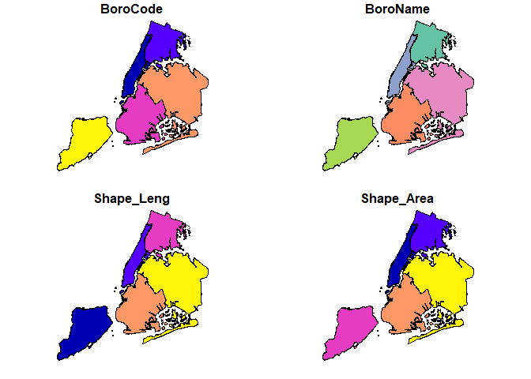

```r
plot(boundaries)
```

We can also plot just the borough names (**BoroName**) by following the object with the variable name in square brackets.

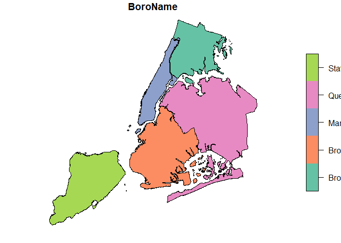

```r
plot(boundaries["BoroName"])
```

Lastly, if we want to only plot the geometry of our shapefile we can include **st_geometry** within our plot function.

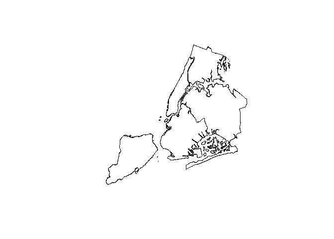

```r
plot(st_geometry(boundaries))
```

## 1.4 Customizable Plotting

Base R plotting is OK, but it can be better. The plotting package **ggplot2** is a standard for **R** users due to the ability to more fully customize plots and, in this case, maps. First, load the **ggplot2** package then call **ggplot()** to create a ggplot object. Next, call **geom_sf()** which is a special geometry call to plot sf objects.

We can plot just the shape of the shapefile by entering no arguments for **geom_sf**. We can also specify border color with **color =** and fill with **fill =**.

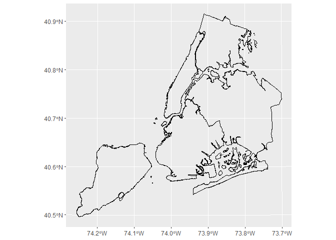

```r
library(ggplot2)

ggplot(data = boundaries) +
  geom_sf(color = "black", fill = NA)
```

We can also plot specific variables of interest by replacing **fill =** with a variable name such as **BoroName**. Because **BoroName** is a character vector, ggplot will assume it is a factor and color it on the map much like a political map where adjacent polygons are displayed in discernible colors.

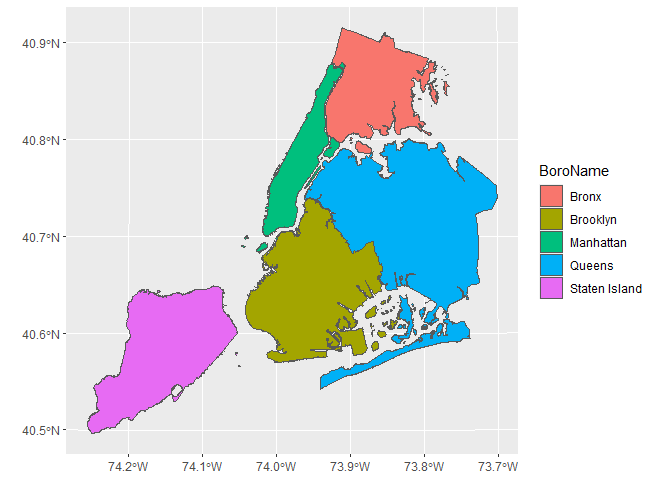

```r
ggplot(data = boundaries) +
  geom_sf(aes(fill = BoroName))
```

## 1.5 Joining Demographic Data to Boundaries

We can also join tabular and spatial data together. This is particularly useful when non-spatialized data can be joined to spatial data based on a common variable such as countries, counties, provinces, etc. In this case, our New York City boundaries do not have any demographic data attached. So we can use the **tidyverse** package and **left_join()** to join the tabular demographic data to the shapefile by borough.

```r
library(tidyverse)
```

```r
join <- boundaries %>%
  left_join(demographic, by = c("BoroName" = "borough"))

head(join, n = 5)
```

```
## Simple feature collection with 5 features and 25 fields
## Geometry type: MULTIPOLYGON
## Dimension:     XY
## Bounding box:  xmin: 913175.1 ymin: 120121.9 xmax: 1049167 ymax: 272844.3
## Projected CRS: NAD83 / New York Long Island (ftUS)
##   BoroCode      BoroName Shape_Leng Shape_Area year     pop under_5 under_18
## 1        5 Staten Island   326060.1 1623676769 2010  476143    0.08    0.218
## 2        5 Staten Island   326060.1 1623676769 2019  468730    0.09    0.248
## 3        5 Staten Island   326060.1 1623676769 2020  478650    0.04    0.258
## 4        2         Bronx   464720.0 1187231178 2010 1418207    0.08    0.246
## 5        2         Bronx   464720.0 1187231178 2019 1384580    0.07    0.286
##   over_65 female white black_aa amer_ind asian haw_pi multi hisp_latino
## 1   0.167  0.514 0.745    0.116    0.007 0.109  0.001 0.022       0.186
## 2   0.217  0.564 0.765    0.166    0.017 0.119  0.031 0.032       0.196
## 3   0.237  0.574 0.775    0.216    0.037 0.159  0.041 0.062       0.226
## 4   0.133  0.528 0.447    0.436    0.029 0.046  0.004 0.038       0.564
## 5   0.143  0.558 0.477    0.466    0.079 0.086  0.054 0.078       0.614
##   white_nohisp veterans foreign housing_units owner_occup median_val
## 1        0.596    14964   0.233        181751       0.693     504800
## 2        0.636    12339   0.253        186491       0.703     497761
## 3        0.656     9883   0.263        227653       0.743     463298
## 4        0.090    25175   0.353        537232       0.197     404700
## 5        0.130    22424   0.373        560204       0.217     438564
##   median_cost_mort median_cost_nomort                       geometry
## 1             2535                905 MULTIPOLYGON (((970217 1456...
## 2             2881                869 MULTIPOLYGON (((970217 1456...
## 3             2984                878 MULTIPOLYGON (((970217 1456...
## 4             2467                795 MULTIPOLYGON (((1012822 229...
## 5             2542                850 MULTIPOLYGON (((1012822 229...
```

## 1.6 Visualizing Continuous Variables

Much like we did with a factor variable, we can also use **ggplot** to map our newly joined demographic data. Here, we map the number of housing units per borough.

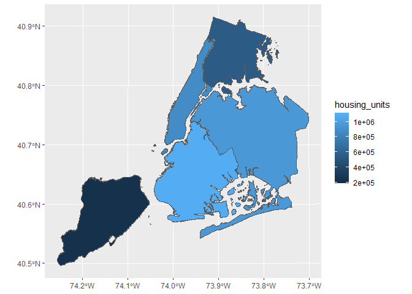

```r
ggplot(data = join) +
  geom_sf(aes(fill = housing_units))
```

## 1.7 Layering Spatial Data

Spatial data and the capabilities of GIS allow for us to layer different shapefiles and rasters on top of each other. The next unit will explain how to do this in analytical ways but for now we can simply map layers on top of one another in the form of a map. We can load and overlay housing rentals on top of our NYC boundaries to see where they are.

```r
rentals <- read.csv("Day 1/data/rent_observations.csv")
head(rentals)
```

```
##    id      long      lat rentvalue year
## 1  90 -73.96068 40.76899        59 1880
## 2  91 -73.96068 40.76899        44 1880
## 3 275 -73.98409 40.76565         9 1880
## 4 276 -73.98409 40.76565        18 1880
## 5 477 -73.98711 40.76676        44 1880
## 6 486 -73.99348 40.75861        40 1880
```

We will need to convert the rental points to a point shapefile. To do this, we can once again use the **sf** package and the **st_as_sf()** function. We simply feed in our data frame object, the coordinate variables in our data frame (X then Y), then define a CRS.

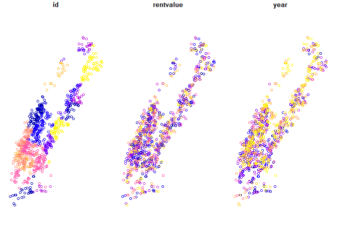

```r
rent_points <- st_as_sf(rentals, coords = c("long","lat"), crs = 4326)

plot(rent_points)
```

Just to make sure we can plot the shapefiles over one another, we need to make sure the CRS of *both* shapefiles is the same; otherwise, the data will not overlap. We can use a simple logical expression to check if they are the same.

```r
st_crs(rent_points) == st_crs(boundaries)
```

```
## [1] FALSE
```

If we return **FALSE** then we should probably make the projections the same using **st_transform**.

```r
rent_points <- st_transform(rent_points, crs = st_crs(boundaries))
```

If we run the crs test again, we should get **TRUE** now.

```r
st_crs(rent_points) == st_crs(boundaries)
```

```
## [1] TRUE
```

Now we can use **ggplot** and multiple **geom_sf()** calls to layer our new map. The package will draw the first layer first then each layer after that. This means we should plot our boundaries first, then our points so that they will appear on top.

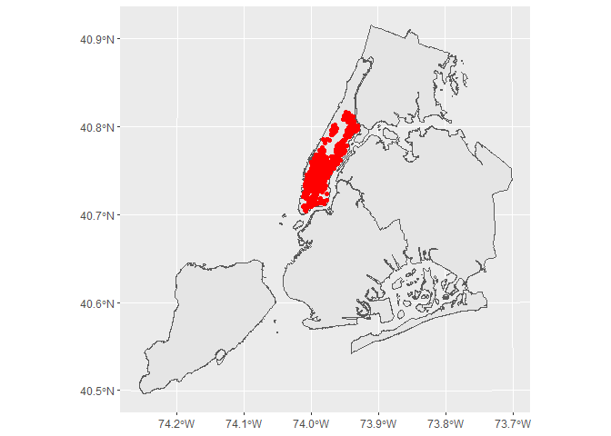

```r
ggplot() +
  geom_sf(data = boundaries) +
  geom_sf(data = rent_points, color = "red")
```

## 1.8 Filtering/Subsetting Spatial Data

Much like how we used the **dplyr** verb **left_join** as part of the larger **tidyverse** package, we can used **filter** to extract rows of interest. This will be useful since our rental observation points are only located in Manhattan.

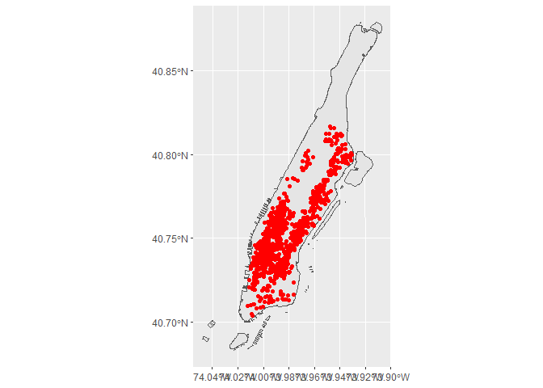

```r
manhattan <- boundaries %>%
  filter(BoroName == "Manhattan")

ggplot() +
  geom_sf(data = manhattan) +
  geom_sf(data = rent_points, color = "red")
```

Now we can plot our overlaid spatial data and color the rental points based on their rent values on a continuous scale.

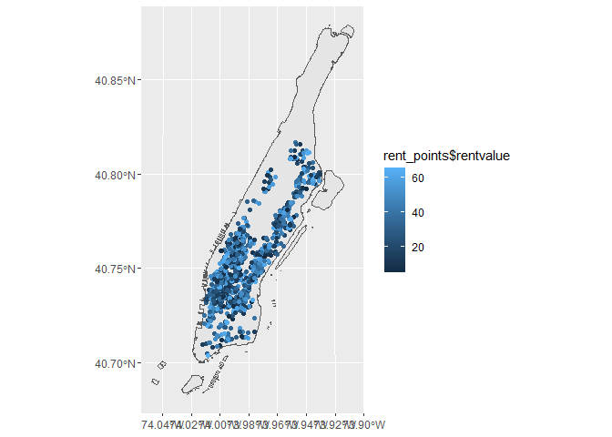

```r
ggplot() +
  geom_sf(data = manhattan) +
  geom_sf(data = rent_points, aes(color = rent_points$rentvalue))
```

## Conclusion

Today we covered some basic functions that will help you take advantage of spatial data in **R**! Like any data analysis, knowing how to read, inspect, explore, manipulate, and visualize data is crucial. We did not cover absolutely everything in this lesson but learning more about **tidyverse**, especially **dplyr** will help you with data cleaning and manipulation.

You can find out about more **dplyr** verbs to select, subset, and more [here](https://dplyr.tidyverse.org/).

If you would like to know more about how to customize plots and maps in **ggplot** you can look [here](https://ggplot2.tidyverse.org/).

Our next lesson will cover common functions of GIS software including spatial relationships, spatial joins, aggregation, and more.